# Tempering the Spread of Epidemics on Aerial Networks

## Students

- Team: `38`
- Students: `<Amaury Combes, Alexis Montavon, Manuel Faysse, Alexandre Daeniker>`
- Dataset: `<Flight Routes>`

## Motivation & Project Scenario

In this study we try to use network properties to find the appropriate way to mitigate the development of a widespread disease, without breaking down the network completely. With this aerial route network, two main idea will be developed: removing important edges and taking down nodes.

June 14, 2019: A new type of infectious disease breaks out and contaminates a small part of the population and. With every passing day, the epidemy spreads across the globe... This is the morbid scenario our project is meant to model. As we are working with flight routes, we model the infection rate of a country by the proportion on infected airports it has. The main idea is that the disease starts in Geneva Airport, chosen because it has a node degree of 100, which is much higher than the average degree (21.03), but is not as connected as a massive airport like Frankfurt (with degree 242). The infection has the ability to spread to $\approx 80\%$ the world in 200 days and stabilise near $81\%$ of infected persons in the population. The purpose of this study is to find a way to reduce the spreading as much as possible while having the smallest possible impact on the network.

## Data extraction

```python
import numpy as np
import pandas as pd
import matplotlib.pyplot as plt
import math
```

```python
# Your code here.
url = 'https://raw.githubusercontent.com/jpatokal/openflights/master/data/airports.dat'
#url = './airports.dat'
airports = pd.read_table(url, sep=',', delimiter=None, header=None)
airports.columns= ['Airport ID','Name', 'City','Country','IATA','ICAO','Lat','Long','Alt (feet)',
                   'Timezone','DST','Tz Database time zone','type','Source']
airports  # the pandas dataframe with the features and labels
```

|  | Airport ID | Name | City | Country | IATA | ICAO | Lat | Long | Alt (feet) | Timezone | DST | Tz Database time zone | type | Source |
| --- | --- | --- | --- | --- | --- | --- | --- | --- | --- | --- | --- | --- | --- | --- |
| 0 | 1 | Goroka Airport | Goroka | Papua New Guinea | GKA | AYGA | -6.081690 | 145.391998 | 5282 | 10 | U | Pacific/Port_Moresby | airport | OurAirports |
| 1 | 2 | Madang Airport | Madang | Papua New Guinea | MAG | AYMD | -5.207080 | 145.789001 | 20 | 10 | U | Pacific/Port_Moresby | airport | OurAirports |
| 2 | 3 | Mount Hagen Kagamuga Airport | Mount Hagen | Papua New Guinea | HGU | AYMH | -5.826790 | 144.296005 | 5388 | 10 | U | Pacific/Port_Moresby | airport | OurAirports |
| 3 | 4 | Nadzab Airport | Nadzab | Papua New Guinea | LAE | AYNZ | -6.569803 | 146.725977 | 239 | 10 | U | Pacific/Port_Moresby | airport | OurAirports |
| 4 | 5 | Port Moresby Jacksons International Airport | Port Moresby | Papua New Guinea | POM | AYPY | -9.443380 | 147.220001 | 146 | 10 | U | Pacific/Port_Moresby | airport | OurAirports |
| 5 | 6 | Wewak International Airport | Wewak | Papua New Guinea | WWK | AYWK | -3.583830 | 143.669006 | 19 | 10 | U | Pacific/Port_Moresby | airport | OurAirports |
| 6 | 7 | Narsarsuaq Airport | Narssarssuaq | Greenland | UAK | BGBW | 61.160500 | -45.425999 | 112 | -3 | E | America/Godthab | airport | OurAirports |
| 7 | 8 | Godthaab / Nuuk Airport | Godthaab | Greenland | GOH | BGGH | 64.190903 | -51.678101 | 283 | -3 | E | America/Godthab | airport | OurAirports |
| 8 | 9 | Kangerlussuaq Airport | Sondrestrom | Greenland | SFJ | BGSF | 67.012222 | -50.711603 | 165 | -3 | E | America/Godthab | airport | OurAirports |
| 9 | 10 | Thule Air Base | Thule | Greenland | THU | BGTL | 76.531197 | -68.703201 | 251 | -4 | E | America/Thule | airport | OurAirports |
| 10 | 11 | Akureyri Airport | Akureyri | Iceland | AEY | BIAR | 65.660004 | -18.072701 | 6 | 0 | N | Atlantic/Reykjavik | airport | OurAirports |
| 11 | 12 | Egilsstaðir Airport | Egilsstadir | Iceland | EGS | BIEG | 65.283302 | -14.401400 | 76 | 0 | N | Atlantic/Reykjavik | airport | OurAirports |
| 12 | 13 | Hornafjörður Airport | Hofn | Iceland | HFN | BIHN | 64.295601 | -15.227200 | 24 | 0 | N | Atlantic/Reykjavik | airport | OurAirports |
| 13 | 14 | Húsavík Airport | Husavik | Iceland | HZK | BIHU | 65.952301 | -17.426001 | 48 | 0 | N | Atlantic/Reykjavik | airport | OurAirports |
| 14 | 15 | Ísafjörður Airport | Isafjordur | Iceland | IFJ | BIIS | 66.058098 | -23.135300 | 8 | 0 | N | Atlantic/Reykjavik | airport | OurAirports |
| 15 | 16 | Keflavik International Airport | Keflavik | Iceland | KEF | BIKF | 63.985001 | -22.605600 | 171 | 0 | N | Atlantic/Reykjavik | airport | OurAirports |
| 16 | 17 | Patreksfjörður Airport | Patreksfjordur | Iceland | PFJ | BIPA | 65.555801 | -23.965000 | 11 | 0 | N | Atlantic/Reykjavik | airport | OurAirports |
| 17 | 18 | Reykjavik Airport | Reykjavik | Iceland | RKV | BIRK | 64.129997 | -21.940599 | 48 | 0 | N | Atlantic/Reykjavik | airport | OurAirports |
| 18 | 19 | Siglufjörður Airport | Siglufjordur | Iceland | SIJ | BISI | 66.133301 | -18.916700 | 10 | 0 | N | Atlantic/Reykjavik | airport | OurAirports |
| 19 | 20 | Vestmannaeyjar Airport | Vestmannaeyjar | Iceland | VEY | BIVM | 63.424301 | -20.278900 | 326 | 0 | N | Atlantic/Reykjavik | airport | OurAirports |
| 20 | 21 | Sault Ste Marie Airport | Sault Sainte Marie | Canada | YAM | CYAM | 46.485001 | -84.509399 | 630 | -5 | A | America/Toronto | airport | OurAirports |
| 21 | 22 | Winnipeg / St. Andrews Airport | Winnipeg | Canada | \N | CYAV | 50.056400 | -97.032501 | 760 | -6 | A | America/Winnipeg | airport | OurAirports |
| 22 | 23 | Halifax / CFB Shearwater Heliport | Halifax | Canada | \N | CYAW | 44.639702 | -63.499401 | 144 | -4 | A | America/Halifax | airport | OurAirports |
| 23 | 24 | St. Anthony Airport | St. Anthony | Canada | YAY | CYAY | 51.391899 | -56.083099 | 108 | -3.5 | A | America/St_Johns | airport | OurAirports |
| 24 | 25 | Tofino / Long Beach Airport | Tofino | Canada | YAZ | CYAZ | 49.079833 | -125.775583 | 80 | -8 | A | America/Vancouver | airport | OurAirports |
| 25 | 26 | Kugaaruk Airport | Pelly Bay | Canada | YBB | CYBB | 68.534401 | -89.808098 | 56 | -7 | A | America/Edmonton | airport | OurAirports |
| 26 | 27 | Baie Comeau Airport | Baie Comeau | Canada | YBC | CYBC | 49.132500 | -68.204399 | 71 | -5 | A | America/Toronto | airport | OurAirports |
| 27 | 28 | CFB Bagotville | Bagotville | Canada | YBG | CYBG | 48.330601 | -70.996399 | 522 | -5 | A | America/Toronto | airport | OurAirports |
| 28 | 29 | Baker Lake Airport | Baker Lake | Canada | YBK | CYBK | 64.298897 | -96.077797 | 59 | -6 | A | America/Winnipeg | airport | OurAirports |
| 29 | 30 | Campbell River Airport | Campbell River | Canada | YBL | CYBL | 49.950802 | -125.271004 | 346 | -8 | A | America/Vancouver | airport | OurAirports |
| ... | ... | ... | ... | ... | ... | ... | ... | ... | ... | ... | ... | ... | ... | ... |
| 7513 | 13636 | Comte. Rolim Adolfo Amaro–Jundiaí State Airport | Jundiai | Brazil | \N | SBJD | -23.180369 | -46.944408 | 2484 | -3 | S | \N | airport | OurAirports |
| 7514 | 13642 | Potomac Airpark | Berkeley Springs | United States | \N | KW35 | 39.692600 | -78.166100 | 412 | -5 | A | \N | airport | OurAirports |
| 7515 | 13643 | Helisul IV Heliport | Foz Do Iguacu | Brazil | \N | SSHS | -25.613056 | -54.398056 | 676 | -3 | N | \N | airport | OurAirports |
| 7516 | 13647 | Brits Airport | Brits | South Africa | \N | FABS | -25.532301 | 27.775900 | 3756 | 2 | U | \N | airport | OurAirports |
| 7517 | 13648 | West Melton Aerodrome | West Melton | New Zealand | \N | NZWL | -43.476700 | 172.397003 | 312 | 12 | Z | \N | airport | OurAirports |
| 7518 | 13649 | Rangiora Airfield | Rangiora | New Zealand | \N | NZRT | -43.290001 | 172.542007 | 180 | 12 | U | \N | airport | OurAirports |
| 7519 | 13668 | JARU Airport | JARU | Brazil | \N | SIDG | -10.423611 | -62.517500 | 550 | -4 | S | \N | airport | OurAirports |
| 7520 | 13669 | Machadinho Airport | MACHADINHO D'OESTE | Brazil | \N | SIMC | -9.403611 | -62.008056 | 450 | -4 | S | \N | airport | OurAirports |
| 7521 | 13671 | Noonkanbah Airport | Noonkanbah | Australia | NKB | YNKA | -18.494699 | 124.851997 | 0 | 8 | N | \N | airport | OurAirports |
| 7522 | 13681 | Chepelevka Airport | Uzyn | Ukraine | \N | UKKH | 49.790600 | 30.441401 | 568 | 2 | E | \N | airport | OurAirports |
| 7523 | 13683 | Fazenda Sao Nicolau Airport | COTRIGUACU | Brazil | \N | SWQT | -9.904444 | -58.582168 | 738 | 0 | U | \N | airport | OurAirports |
| 7524 | 13687 | Kasese Airport | Kasese | Uganda | KSE | HUKS | 0.183000 | 30.100000 | 3146 | 3 | N | \N | airport | OurAirports |
| 7525 | 13694 | Stennis International Airport | Bay St. Louis | United States | \N | KHSA | 30.367800 | -89.454597 | 23 | -5 | A | \N | airport | OurAirports |
| 7526 | 13707 | Seldovia Airport | Seldovia | United States | SOV | PASO | 59.442402 | -151.703995 | 29 | -9 | A | \N | airport | OurAirports |
| 7527 | 13711 | Lutselk'e Airport | Lutselk'e | Canada | YSG | CYLK | 62.418303 | -110.681998 | 596 | \N | \N | \N | airport | OurAirports |
| 7528 | 13712 | Engeløy Airport | Engeløy | Norway | \N | ENEN | 67.967222 | 14.992500 | 0 | \N | \N | \N | airport | OurAirports |
| 7529 | 13713 | Dwangwa Airport | Dwangwa | Malawi | DWA | FWDW | -12.518300 | 34.131901 | 1605 | \N | \N | \N | airport | OurAirports |
| 7530 | 13714 | Paloich Airport, Heliport | Higleig | South Sudan | HGI | HSFA | 10.529167 | 32.500556 | 1290 | \N | \N | \N | airport | OurAirports |
| 7531 | 13715 | Julian Carroll Airport | Jackson | United States | \N | KJKL | 37.593899 | -83.317299 | 1381 | \N | \N | \N | airport | OurAirports |
| 7532 | 13716 | Beaufort MCAS - Merritt Field | Beaufort | United States | \N | KNBC | 32.477402 | -80.723198 | 37 | \N | \N | \N | airport | OurAirports |
| 7533 | 13717 | Camp Pendleton MCAS (Munn Field) Airport | Oceanside | United States | \N | KNFG | 33.301300 | -117.355003 | 78 | \N | \N | \N | airport | OurAirports |
| 7534 | 13718 | Aerodromo de Castelo Branco | Castelo Branco | Portugal | \N | LPCB | 39.847022 | -7.441110 | 1300 | \N | \N | \N | airport | OurAirports |
| 7535 | 13719 | Ponte de Sor Airport | Ponte de Sôr | Portugal | \N | LPSO | 39.211559 | -8.056542 | 0 | \N | \N | \N | airport | OurAirports |
| 7536 | 13720 | Vilar Da Luz Airport | Maia | Portugal | \N | LPVL | 41.277290 | -8.516207 | 0 | \N | \N | \N | airport | OurAirports |
| 7537 | 13721 | Hard Bargain Airport | NaN | Bahamas | \N | MYLR | 23.011194 | -74.905889 | 0 | \N | \N | \N | airport | OurAirports |
| 7538 | 13722 | Kenebetsu JASDF Airfield | Kenebetsu | Japan | \N | RJCS | 43.425154 | 144.741354 | 0 | \N | \N | \N | airport | OurAirports |
| 7539 | 13723 | Augusto Severo Airport | Natal | Brazil | \N | SBNT | -5.911420 | -35.247700 | 169 | \N | \N | \N | airport | OurAirports |
| 7540 | 13724 | Kishangarh Airport | Ajmer | India | KQH | VIKG | 26.601473 | 74.814147 | 0 | \N | \N | \N | airport | OurAirports |
| 7541 | 13725 | Kannur International Airport | Kannur | India | CNN | VOKN | 11.918614 | 75.547211 | 330 | \N | \N | \N | airport | OurAirports |
| 7542 | 13726 | Beijing Xijiao Airport | Beijing | China | \N | ZBBB | 39.960800 | 116.257004 | 0 | \N | \N | \N | airport | OurAirports |

7543 rows × 14 columns

```python
airports[airports['Airport ID'] == 340]
```

|  | Airport ID | Name | City | Country | IATA | ICAO | Lat | Long | Alt (feet) | Timezone | DST | Tz Database time zone | type | Source |
| --- | --- | --- | --- | --- | --- | --- | --- | --- | --- | --- | --- | --- | --- | --- |
| 336 | 340 | Frankfurt am Main Airport | Frankfurt | Germany | FRA | EDDF | 50.033333 | 8.570556 | 364 | 1 | E | Europe/Berlin | airport | OurAirports |

```python
url = 'https://raw.githubusercontent.com/jpatokal/openflights/master/data/routes.dat'
routes = pd.read_table(url, sep=',', delimiter=None, header=None)
routes.columns= ['Airline','Airline ID', 'Source Airport','Source_Airport_ID',
                 'Destination Airport', 'Destination_Airport_ID','Codeshare','Stops','Equipment']
routes.head(10)
```

|  | Airline | Airline ID | Source Airport | Source_Airport_ID | Destination Airport | Destination_Airport_ID | Codeshare | Stops | Equipment |
| --- | --- | --- | --- | --- | --- | --- | --- | --- | --- |
| 0 | 2B | 410 | AER | 2965 | KZN | 2990 | NaN | 0 | CR2 |
| 1 | 2B | 410 | ASF | 2966 | KZN | 2990 | NaN | 0 | CR2 |
| 2 | 2B | 410 | ASF | 2966 | MRV | 2962 | NaN | 0 | CR2 |
| 3 | 2B | 410 | CEK | 2968 | KZN | 2990 | NaN | 0 | CR2 |
| 4 | 2B | 410 | CEK | 2968 | OVB | 4078 | NaN | 0 | CR2 |
| 5 | 2B | 410 | DME | 4029 | KZN | 2990 | NaN | 0 | CR2 |
| 6 | 2B | 410 | DME | 4029 | NBC | 6969 | NaN | 0 | CR2 |
| 7 | 2B | 410 | DME | 4029 | TGK | \N | NaN | 0 | CR2 |
| 8 | 2B | 410 | DME | 4029 | UUA | 6160 | NaN | 0 | CR2 |
| 9 | 2B | 410 | EGO | 6156 | KGD | 2952 | NaN | 0 | CR2 |

```python
routes2 = routes.copy()
airports2 = airports.copy()
```

```python
edges = routes2[['Source_Airport_ID','Destination_Airport_ID']]
edges.Source_Airport_ID = pd.to_numeric(edges.Source_Airport_ID, 'coerce').dropna()
edges.Destination_Airport_ID = pd.to_numeric(edges.Destination_Airport_ID, 'coerce').dropna()
edges2 = edges.copy()
edges.head()
```

|  | Source_Airport_ID | Destination_Airport_ID |
| --- | --- | --- |
| 0 | 2965.0 | 2990.0 |
| 1 | 2966.0 | 2990.0 |
| 2 | 2966.0 | 2962.0 |
| 3 | 2968.0 | 2990.0 |
| 4 | 2968.0 | 4078.0 |

```python
airports2.reset_index(level=0, inplace=True)
airportID = airports2[['Airport ID', 'Name','City','Country']]
airportID.reset_index(inplace=True)
airportID = airportID.rename(columns={'index':'airport_idx'})
airportID.head()
```

|  | airport_idx | Airport ID | Name | City | Country |
| --- | --- | --- | --- | --- | --- |
| 0 | 0 | 1 | Goroka Airport | Goroka | Papua New Guinea |
| 1 | 1 | 2 | Madang Airport | Madang | Papua New Guinea |
| 2 | 2 | 3 | Mount Hagen Kagamuga Airport | Mount Hagen | Papua New Guinea |
| 3 | 3 | 4 | Nadzab Airport | Nadzab | Papua New Guinea |
| 4 | 4 | 5 | Port Moresby Jacksons International Airport | Port Moresby | Papua New Guinea |

```python
ID2idx= airportID[['airport_idx', 'Airport ID']]
ID2idx = ID2idx.set_index('Airport ID')
ID2idx.head()
```

| Airport ID | airport_idx |
| --- | --- |
| 1 | 0 |
| 2 | 1 |
| 3 | 2 |
| 4 | 3 |
| 5 | 4 |

```python
len(ID2idx)
```

```
7543
```

```python
edges2 = edges.join(ID2idx, on='Source_Airport_ID', rsuffix='_source')
edges2 = edges2.join(ID2idx, on='Destination_Airport_ID', rsuffix='_dest')
edges2=edges2.dropna()

edges2.head()
```

|  | Source_Airport_ID | Destination_Airport_ID | airport_idx | airport_idx_dest |
| --- | --- | --- | --- | --- |
| 0 | 2965.0 | 2990.0 | 2809.0 | 2831.0 |
| 1 | 2966.0 | 2990.0 | 2810.0 | 2831.0 |
| 2 | 2966.0 | 2962.0 | 2810.0 | 2806.0 |
| 3 | 2968.0 | 2990.0 | 2812.0 | 2831.0 |
| 4 | 2968.0 | 4078.0 | 2812.0 | 3855.0 |

```python
len(edges2)
```

```
66103
```

```python
n_nodes = len(ID2idx)
adjacency = np.zeros((n_nodes, n_nodes), dtype=int)
```

```python
for idx, row in edges2.iterrows():
    if (np.isnan(row.airport_idx)):
        continue
    if (np.isnan(row.airport_idx_dest)):
        continue
    i, j = int(row.airport_idx), int(row.airport_idx_dest)
    adjacency[i, j] += 1
```

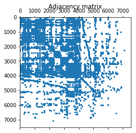

```python
plt.spy(adjacency, markersize=2)
plt.title('Adjacency matrix')
```

#### Removing nodes with no edges

```python
x = np.where(np.sum(adjacency, axis=1) > 0.0)
```

```python
x[0]
```

```
array([   0,    1,    2, ..., 6881, 6885, 7089])
```

```python
A = adjacency[x[0]]
```

```python
A2 = A[:, x[0]]
```

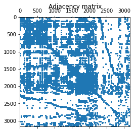

```python
plt.spy(A2, markersize=2)
plt.title('Adjacency matrix')
```

```python
def check_symmetric(a, tol=1e-8):
    return np.allclose(a, a.T, atol=tol)
```

```python
check_symmetric(A2)
```

```
False
```

```python
Mapping = dict(zip(range(len(x[0])), x[0]))
```

```python
oldMap = ID2idx.to_dict()
```

```python
oldMap2 = {value: key for key, value in list(oldMap.values())[0].items()}
```

```python
Mapping2 = {value: key for key, value in Mapping.items()}
```

```python
def indxToAirportID(x):
    return oldMap2[Mapping[x]]
```

```python
indxToAirportID(0)
```

```
1
```

```python
def AirportIDtoIndx(x):
    return Mapping2[list(oldMap.values())[0][x]]
```

```python
AirportIDtoIndx(1665)
```

```
753
```

```python
indxToAirportID(753)
```

```
1665
```

### Plot Airports On World Map (example with 300 airports)

```python
import folium
from random import randint
```

```python
airports2 = airports2.set_index('Airport ID')
```

```python
rand = np.random.randint(3000, size=300)
```

```python
m=folium.Map(
    location=[20, 0],
    tiles='Mapbox Bright',
    zoom_start=2
)


for i in rand:
    loc = airports2.loc[indxToAirportID(i)].Lat,airports2.loc[indxToAirportID(i)].Long
    popupName = airports2.Name[indxToAirportID(i)]
    folium.Marker(
    location=loc,
    popup=popupName,
    icon=folium.Icon(color='red',icon = 'plane')
).add_to(m)

m
```

[interactive chart not shown]

## SIS simulation

```python
import networkx as nx
```

### Create Graph, add weights and study some properties

```python
G = nx.from_numpy_array(A2)
```

```python
len(G.nodes)
```

```
3169
```

```python
for edge in G.edges:
    G[edge[0]][edge[1]]['weight'] = A2[edge[0]][edge[1]]
```

```python
G.get_edge_data(89, 125)
```

```
{'weight': 6}
```

```python
#Using only giant connected component
giant_comp = max(nx.connected_component_subgraphs(G), key=len)
```

```python
len(giant_comp.edges)
```

```
18587
```

```python
#Diameter of the giant component
nx.diameter(giant_comp)
```

```
12
```

```python
#Average shortest path of the giant component
nx.average_shortest_path_length(giant_comp)
```

```
3.949984334662642
```

```python
def average_degree(g):
    return  sum(dict(g.degree(weight='weight')).values()) / len(g.nodes())
```

```python
#Average degree of the giant component
average_degree(giant_comp)
```

```
21.037861915367483
```

### Configure simulation

```python
import ndlib.models.ModelConfig as mc
import ndlib.models.epidemics.SISModel as sis
from bokeh.io import output_notebook, show
from ndlib.viz.bokeh.DiffusionTrend import DiffusionTrend

output_notebook()
```

```python
def simulate_SIS(G, beta=0.01, lambda_=0.005, initial_node=753): ##GVA index
    model = sis.SISModel(G)

    cfg = mc.Configuration()
    infected_nodes = [initial_node]
    cfg.add_model_initial_configuration("Infected", infected_nodes)
    cfg.add_model_parameter('beta', beta)
    cfg.add_model_parameter('lambda', lambda_)

    model.set_initial_status(cfg)
    iterations = model.iteration_bunch(800)

    trends = model.build_trends(iterations)

    return trends, iterations, model
```

```python
trends, iterations, model = simulate_SIS(giant_comp)
```

```python
viz = DiffusionTrend(model, trends)
p = viz.plot(width=500, height=500)
p.legend.location = "center_right"
show(p)
```

[interactive chart not shown]

```python
import folium
import geopandas as gpd
from branca.colormap import linear
from folium.plugins import TimeSliderChoropleth
import numpy as np
import os

datapath = 'world.geo.json'
gdf = gpd.read_file(datapath)

%matplotlib inline

def makeMap(iterations):
    dicofdic = {}

    checkpoints = range(0,800,100)

    for itera in checkpoints:
        dic = {}
        dicCountries = {}
        dicInfected = {}

        #itera = 100

        for i in range(itera):
            for key in iterations[i]['status']:
                dic[key] = iterations[i]['status'][key]

        for a in dic:
            if airports2.loc[indxToAirportID(a)]['Country'] in dicInfected:
                dicInfected[airports2.loc[indxToAirportID(a)]['Country']] += dic[a]
            else:
                dicInfected[airports2.loc[indxToAirportID(a)]['Country']] = dic[a]



        nodes = list(giant_comp)
        for a in nodes:
            if airports2.loc[indxToAirportID(a)]['Country'] in dicCountries:
                dicCountries[airports2.loc[indxToAirportID(a)]['Country']] += 1
            else:
                dicCountries[airports2.loc[indxToAirportID(a)]['Country']] = 1

        for key in dicCountries:
            if key in dicInfected:
                dicCountries[key] = dicInfected[key]/dicCountries[key]
            else:
                dicCountries[key] = 0

        dicofdic[itera]  = dicCountries


    n_periods, n_sample = len(checkpoints),len(checkpoints)

    assert n_sample <= n_periods

    datetime_index = pd.date_range('2019-1-1', periods=n_periods, freq='10D')
    dt_index_epochs = datetime_index.astype(int) // 10**9
    dt_index = dt_index_epochs.astype('U10')

    styledata = {}

    for country in gdf.index:

        vec = []
        for i in checkpoints:
            try:
                vec.append(dicofdic[i][gdf.loc[country]['name']])
            except:
                vec = 0*np.ones(len(checkpoints))

        df = pd.DataFrame(
            {'color': np.array(vec)*10 ,
             'opacity': 0.5*np.ones(len(checkpoints))},
            index=dt_index
        )
        #df = df.cumsum()
        df.sample(n_sample, replace=False).sort_index()
        styledata[country] = df



    max_color, min_color, max_opacity, min_opacity = 0, 0, 0, 0

    for country, data in styledata.items():
        max_color = max(max_color, data['color'].max())
        min_color = min(max_color, data['color'].min())
        max_opacity = max(max_color, data['opacity'].max())
        max_opacity = min(max_color, data['opacity'].max())



    cmap = linear.YlOrRd_09.scale(min_color, max_color)


    def norm(x):
        return (x - x.min()) / (x.max() - x.min())


    for country, data in styledata.items():
        data['color'] = data['color'].apply(cmap)

    styledict = { str(country): data.to_dict(orient='index') for country, data in styledata.items()}

    m = folium.Map([0, 0], tiles='OpenStreetMap', zoom_start=2)

    g = TimeSliderChoropleth(
        gdf.to_json(),
        styledict=styledict,

    ).add_to(m)

    m.save(os.path.join('TimeSliderChoropleth.html'))

    return m
```

### Epidemic visualisation by country

```python
makeMap(iterations)
```

[interactive chart not shown]

## Mitigate the infection

```python
from tqdm import tqdm_notebook
```

```python
def plot_trends(trends):
    viz = DiffusionTrend(model, trends)
    p = viz.plot(width=500, height=500)
    p.legend.location = "center_right"
    show(p)


def extract_final_state(trends):
    return trends[0]['trends']['node_count'][0][-1], trends[0]['trends']['node_count'][1][-1]


def extract_suspected_count_history(trends):
    return trends['trends']['node_count'][0]


def extract_infection_states(experiment_history):
    infection_states = [(alteration_lvl, final_state[1] / (final_state[0] + final_state[1]))\
                        for alteration_lvl, graph, final_state, trends in experiment_history]

    return infection_states
```

```python
simulate_e1_SIS = lambda G, initial_node: simulate_SIS(G, beta=0.01, lambda_=0.005, initial_node=initial_node)
```

```python
def spread_reduction_experiment(G, simulateSIS, experiment_count, sample_count, alterator, initial_node):
    history = []

    alterator.register(G)

    for i in tqdm_notebook(range(experiment_count)):
        altered_G, alteration_level = alterator.alter(G, i, initial_node)

        logs = [simulateSIS(altered_G, initial_node)[0] for j in range(sample_count)]

        average_final_state = np.mean([extract_final_state(log) for log in logs], axis=0)

        history += [(alteration_level, altered_G, average_final_state, logs[-1])]

    return history
```

### Removing nodes by degree

```python
class SimpleAlterator:

    def register(self, G):
        degree_per_node = G.degree()

        self.ranked_nodes = sorted(dict(degree_per_node).keys(),\
                      key=lambda node: -degree_per_node[node])

    def alter(self, G, i, initial_node):
        tmp_G = G.copy()

        alteration_level = 50*i
        for node in self.ranked_nodes[:alteration_level]:
            if node != initial_node:
                tmp_G.remove_node(node)

        return tmp_G, alteration_level
```

```python
simple_history = spread_reduction_experiment(giant_comp, simulate_e1_SIS, 20, 10, SimpleAlterator(), 753)
```

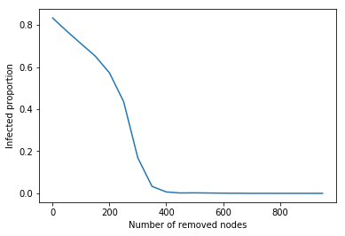

```python
final_infection_states = np.array(extract_infection_states(simple_history))

plt.plot(final_infection_states[:,0], final_infection_states[:,1])
plt.xlabel('Number of removed nodes')
plt.ylabel('Infected proportion')
plt.show()
```

As we can see on the plot above, removing nodes with high degree is an effective strategy. Indeed, after removing 400 nodes with high degree, the epidemic will always die after 500 iterations.

### Removing nodes without breaking connectivity

#### Removing by degree

Even though the suggested strategy above works, it is very restrictive as the graph is not connected anymore and we thus loose the full power of the aerial network. In the following, we will explore a few alteration strategies that preserves the connectedness property of our network while reducing the epidemic’s spread. The first strategy will remove nodes based on their degree, the second on the closeness value and the third on the betweenness value. But those times the graph will still be connected, so anyone can go from any airport to any other.

```python
class ByDegreeAlterator:

    def register(self, G):
        degree_per_node = G.degree()

        self.ranked_nodes = sorted(dict(degree_per_node).keys(),\
                      key=lambda node: -degree_per_node[node])

    def alter(self, G, i, initial_node):
        tmp_G = G.copy()

        alteration_level = 50*i

        for node in self.ranked_nodes[:alteration_level]:
            edges = list(tmp_G.edges(node))

            if node != initial_node:
                tmp_G.remove_node(node)

            if not nx.is_connected(tmp_G):
                    tmp_G.add_node(node)
                    tmp_G.add_edges_from(edges)

        return tmp_G, alteration_level
```

```python
by_degree_history = spread_reduction_experiment(giant_comp, simulate_e1_SIS, 20, 10, ByDegreeAlterator(), 753)
```

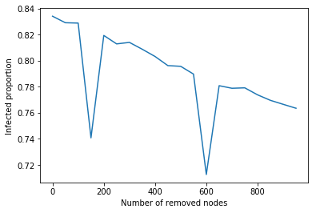

```python
final_infection_states = np.array(extract_infection_states(by_degree_history))

plt.plot(final_infection_states[:,0], final_infection_states[:,1])
plt.xlabel('Number of removed nodes')
plt.ylabel('Infected proportion')
plt.show()
```

Here for comparison the simulation with 900 nodes removed, we can see that in the same amount of iterations, the virus only infects about 6% less of the globe

```python
new_g = by_degree_history[-1][1]
trends, iterations, model = simulate_SIS(new_g)
viz = DiffusionTrend(model, trends)
p = viz.plot(width=500, height=500)
p.legend.location = "center_right"
show(p)
```

[interactive chart not shown]

```python
nx.diameter(new_g)
```

```
24
```

```python
nx.average_shortest_path_length(new_g)
```

```
4.718146949071004
```

```python
average_degree(new_g)
```

```
4.823055219669488
```

```python
makeMap(iterations)
```

[interactive chart not shown]

#### Removing by closeness

```python
class ByClosenessAlterator:

    def register(self, G):
        closeness_centrality_per_node = nx.closeness_centrality(G)

        self.ranked_nodes = sorted(dict(closeness_centrality_per_node).keys(),\
                      key=lambda node: -closeness_centrality_per_node[node])

    def alter(self, G, i, initial_node):
        tmp_G = G.copy()

        alteration_level = 50*i

        for node in self.ranked_nodes[:alteration_level]:
            edges = list(tmp_G.edges(node))

            if node != initial_node:
                tmp_G.remove_node(node)

            if not nx.is_connected(tmp_G):
                    tmp_G.add_node(node)
                    tmp_G.add_edges_from(edges)

        return tmp_G, alteration_level
```

```python
by_closeness_history = spread_reduction_experiment(giant_comp, simulate_e1_SIS, 20, 10, ByClosenessAlterator(), 753)
```

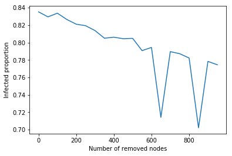

```python
final_infection_states = np.array(extract_infection_states(by_closeness_history))

plt.plot(final_infection_states[:,0], final_infection_states[:,1])
plt.xlabel('Number of removed nodes')
plt.ylabel('Infected proportion')
plt.show()
```

Here for comparison the simulation with 900 nodes removed, we can see that in the same amount of iterations, the virus only infects about 5% less of the globe

```python
new_g = by_closeness_history[-1][1]
trends, iterations, model = simulate_SIS(new_g)
viz = DiffusionTrend(model, trends)
p = viz.plot(width=500, height=500)
p.legend.location = "center_right"
show(p)
```

[interactive chart not shown]

```python
nx.diameter(new_g)
```

```
21
```

```python
nx.average_shortest_path_length(new_g)
```

```
4.725317071833052
```

```python
average_degree(new_g)
```

```
5.376655629139073
```

```python
makeMap(iterations)
```

[interactive chart not shown]

#### Removing by betweeness

```python
class ByBetweennessAlterator:

    def register(self, G):
        betweenness_centrality_per_node = nx.betweenness_centrality(G)

        self.ranked_nodes = sorted(dict(betweenness_centrality_per_node).keys(),\
                      key=lambda node: -betweenness_centrality_per_node[node])

    def alter(self, G, i, initial_node):
        tmp_G = G.copy()

        alteration_level = 50*i

        for node in self.ranked_nodes[:alteration_level]:
            edges = list(tmp_G.edges(node))

            if node != initial_node:
                tmp_G.remove_node(node)

            if not nx.is_connected(tmp_G):
                    tmp_G.add_node(node)
                    tmp_G.add_edges_from(edges)

        return tmp_G, alteration_level
```

```python
by_betweenness_history = spread_reduction_experiment(giant_comp, simulate_e1_SIS, 20, 10, ByBetweennessAlterator(), 753)
```

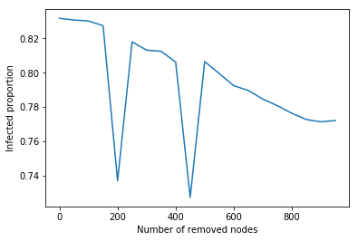

```python
final_infection_states = np.array(extract_infection_states(by_betweenness_history))

plt.plot(final_infection_states[:,0], final_infection_states[:,1])
plt.xlabel('Number of removed nodes')
plt.ylabel('Infected proportion')
plt.show()
```

Here for comparison the simulation with 900 nodes removed, we can see that in the same amount of iterations, the virus only infects about 6% less of the globe.

```python
new_g = by_betweenness_history[-1][1]
trends, iterations, model = simulate_SIS(new_g)
viz = DiffusionTrend(model, trends)
p = viz.plot(width=500, height=500)
p.legend.location = "center_right"
show(p)
```

[interactive chart not shown]

```python
nx.diameter(new_g)
```

```
24
```

```python
nx.average_shortest_path_length(new_g)
```

```
4.459601395106095
```

```python
average_degree(new_g)
```

```
8.729325805380272
```

```python
makeMap(iterations)
```

[interactive chart not shown]

### Removing edges

```python
class ByEdgeBetweennessAlterator:

    def register(self, G):
        betweenness_centrality_per_edge = nx.edge_betweenness_centrality(G)

        self.ranked_edges = sorted(dict(betweenness_centrality_per_edge).keys(),\
                      key=lambda edge: -betweenness_centrality_per_edge[edge])

    def alter(self, G, i, initial_node):
        tmp_G = G.copy()

        alteration_level = 300*i

        for edge in self.ranked_edges[:alteration_level]:
            tmp_G.remove_edge(*edge)

            if not nx.is_connected(tmp_G):
                tmp_G.add_edge(*edge)

        return tmp_G, alteration_level
```

```python
by_edge_betweenness_history = spread_reduction_experiment(giant_comp, simulate_e1_SIS, 20, 10,\
                                                          ByEdgeBetweennessAlterator(), 753)
```

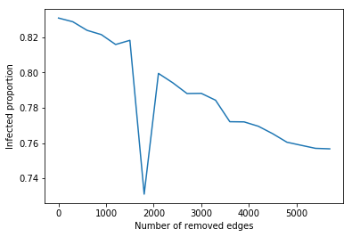

```python
final_infection_states = np.array(extract_infection_states(by_edge_betweenness_history))

plt.plot(final_infection_states[:,0], final_infection_states[:,1])
plt.xlabel('Number of removed edges')
plt.ylabel('Infected proportion')
plt.show()
```

```python
new_g = by_edge_betweenness_history[-1][1]
trends, iterations, model = simulate_SIS(new_g)
viz = DiffusionTrend(model, trends)
p = viz.plot(width=500, height=500)
p.legend.location = "center_right"
show(p)
```

[interactive chart not shown]

```python
nx.diameter(new_g)
```

```
26
```

```python
nx.average_shortest_path_length(new_g)
```

```
6.494619407236596
```

```python
average_degree(new_g)
```

```
15.154947502386255
```

```python
makeMap(iterations)
```

[interactive chart not shown]

## Conclusion

To conclude we applied three different techniques to reduce de propagation of a very infectious disease through the airline network. It seems that removing edges based on the edge betweenness is the best solution, although it is increases harshly the average shortest path.